# Risk Factor Analysis

## Outcome Variable

**Outcome Variable:** haz

## Predictor Variables

**Intervention Variable:** hfoodsec

**Adjustment Set:**

- arm
- sex
- W_mage
- meducyrs
- feducyrs
- hhwealth_quart
- vagbrth
- W_nrooms
- W_nchldlt5
- brthmon
- W_parity
- impfloor
- impsan
- safeh20
- delta_W_mage
- delta_meducyrs
- delta_feducyrs
- delta_hhwealth_quart
- delta_vagbrth
- delta_W_nrooms
- delta_W_nchldlt5
- delta_brthmon
- delta_W_parity
- delta_impfloor
- delta_impsan
- delta_safeh20

## Stratifying Variables

The analysis was stratified on these variable(s):

- agecat
- studyid
- country

## Data Summary

| agecat | studyid | country | hfoodsec | n_cell | n | outcome_variable |
| --- | --- | --- | --- | --- | --- | --- |
| Birth | ki0047075b-MAL-ED | BANGLADESH | Food Secure | 144 | 172 | haz |
| Birth | ki0047075b-MAL-ED | BANGLADESH | Mildly Food Insecure | 4 | 172 | haz |
| Birth | ki0047075b-MAL-ED | BANGLADESH | Food Insecure | 24 | 172 | haz |
| Birth | ki0047075b-MAL-ED | BRAZIL | Food Secure | 0 | 28 | haz |
| Birth | ki0047075b-MAL-ED | BRAZIL | Mildly Food Insecure | 4 | 28 | haz |
| Birth | ki0047075b-MAL-ED | BRAZIL | Food Insecure | 24 | 28 | haz |
| Birth | ki0047075b-MAL-ED | INDIA | Food Secure | 34 | 37 | haz |
| Birth | ki0047075b-MAL-ED | INDIA | Mildly Food Insecure | 1 | 37 | haz |
| Birth | ki0047075b-MAL-ED | INDIA | Food Insecure | 2 | 37 | haz |
| Birth | ki0047075b-MAL-ED | NEPAL | Food Secure | 10 | 14 | haz |
| Birth | ki0047075b-MAL-ED | NEPAL | Mildly Food Insecure | 1 | 14 | haz |
| Birth | ki0047075b-MAL-ED | NEPAL | Food Insecure | 3 | 14 | haz |
| Birth | ki0047075b-MAL-ED | PERU | Food Secure | 24 | 91 | haz |
| Birth | ki0047075b-MAL-ED | PERU | Mildly Food Insecure | 23 | 91 | haz |
| Birth | ki0047075b-MAL-ED | PERU | Food Insecure | 44 | 91 | haz |
| Birth | ki0047075b-MAL-ED | SOUTH AFRICA | Food Secure | 45 | 88 | haz |
| Birth | ki0047075b-MAL-ED | SOUTH AFRICA | Mildly Food Insecure | 9 | 88 | haz |
| Birth | ki0047075b-MAL-ED | SOUTH AFRICA | Food Insecure | 34 | 88 | haz |
| Birth | ki1017093-NIH-Birth | BANGLADESH | Food Secure | 90 | 608 | haz |
| Birth | ki1017093-NIH-Birth | BANGLADESH | Mildly Food Insecure | 478 | 608 | haz |
| Birth | ki1017093-NIH-Birth | BANGLADESH | Food Insecure | 40 | 608 | haz |
| Birth | ki1017093c-NIH-Crypto | BANGLADESH | Food Secure | 439 | 732 | haz |
| Birth | ki1017093c-NIH-Crypto | BANGLADESH | Mildly Food Insecure | 209 | 732 | haz |
| Birth | ki1017093c-NIH-Crypto | BANGLADESH | Food Insecure | 84 | 732 | haz |
| Birth | ki1113344-GMS-Nepal | NEPAL | Food Secure | 477 | 672 | haz |
| Birth | ki1113344-GMS-Nepal | NEPAL | Mildly Food Insecure | 106 | 672 | haz |
| Birth | ki1113344-GMS-Nepal | NEPAL | Food Insecure | 89 | 672 | haz |
| Birth | kiGH5241-JiVitA-3 | BANGLADESH | Food Secure | 6951 | 14364 | haz |
| Birth | kiGH5241-JiVitA-3 | BANGLADESH | Mildly Food Insecure | 4877 | 14364 | haz |
| Birth | kiGH5241-JiVitA-3 | BANGLADESH | Food Insecure | 2536 | 14364 | haz |

[output cut: 69 more lines]

The following strata were considered:

- agecat: 24 months, studyid: ki0047075b-MAL-ED, country: BANGLADESH
- agecat: 24 months, studyid: ki0047075b-MAL-ED, country: BRAZIL
- agecat: 24 months, studyid: ki0047075b-MAL-ED, country: INDIA
- agecat: 24 months, studyid: ki0047075b-MAL-ED, country: NEPAL
- agecat: 24 months, studyid: ki0047075b-MAL-ED, country: PERU
- agecat: 24 months, studyid: ki0047075b-MAL-ED, country: SOUTH AFRICA
- agecat: 24 months, studyid: ki1017093-NIH-Birth, country: BANGLADESH
- agecat: 24 months, studyid: ki1017093c-NIH-Crypto, country: BANGLADESH
- agecat: 24 months, studyid: ki1113344-GMS-Nepal, country: NEPAL
- agecat: 24 months, studyid: kiGH5241-JiVitA-3, country: BANGLADESH
- agecat: 24 months, studyid: kiGH5241-JiVitA-4, country: BANGLADESH
- agecat: 6 months, studyid: ki0047075b-MAL-ED, country: BANGLADESH
- agecat: 6 months, studyid: ki0047075b-MAL-ED, country: BRAZIL
- agecat: 6 months, studyid: ki0047075b-MAL-ED, country: INDIA
- agecat: 6 months, studyid: ki0047075b-MAL-ED, country: NEPAL
- agecat: 6 months, studyid: ki0047075b-MAL-ED, country: PERU
- agecat: 6 months, studyid: ki0047075b-MAL-ED, country: SOUTH AFRICA
- agecat: 6 months, studyid: ki1017093-NIH-Birth, country: BANGLADESH
- agecat: 6 months, studyid: ki1017093c-NIH-Crypto, country: BANGLADESH
- agecat: 6 months, studyid: ki1113344-GMS-Nepal, country: NEPAL
- agecat: 6 months, studyid: kiGH5241-JiVitA-3, country: BANGLADESH
- agecat: 6 months, studyid: kiGH5241-JiVitA-4, country: BANGLADESH
- agecat: Birth, studyid: ki0047075b-MAL-ED, country: BANGLADESH
- agecat: Birth, studyid: ki0047075b-MAL-ED, country: BRAZIL
- agecat: Birth, studyid: ki0047075b-MAL-ED, country: INDIA
- agecat: Birth, studyid: ki0047075b-MAL-ED, country: NEPAL
- agecat: Birth, studyid: ki0047075b-MAL-ED, country: PERU
- agecat: Birth, studyid: ki0047075b-MAL-ED, country: SOUTH AFRICA
- agecat: Birth, studyid: ki1017093-NIH-Birth, country: BANGLADESH
- agecat: Birth, studyid: ki1017093c-NIH-Crypto, country: BANGLADESH
- agecat: Birth, studyid: ki1113344-GMS-Nepal, country: NEPAL
- agecat: Birth, studyid: kiGH5241-JiVitA-3, country: BANGLADESH
- agecat: Birth, studyid: kiGH5241-JiVitA-4, country: BANGLADESH

### Dropped Strata

Some strata were dropped due to rare outcomes:

- agecat: Birth, studyid: ki0047075b-MAL-ED, country: BANGLADESH
- agecat: Birth, studyid: ki0047075b-MAL-ED, country: BRAZIL
- agecat: Birth, studyid: ki0047075b-MAL-ED, country: INDIA
- agecat: Birth, studyid: ki0047075b-MAL-ED, country: NEPAL
- agecat: 6 months, studyid: ki0047075b-MAL-ED, country: BANGLADESH
- agecat: 6 months, studyid: ki0047075b-MAL-ED, country: BRAZIL
- agecat: 24 months, studyid: ki0047075b-MAL-ED, country: BANGLADESH
- agecat: 24 months, studyid: ki0047075b-MAL-ED, country: BRAZIL

## Methods Detail

We’re interested in the causal parameters $E[Y_a]$ for all values of $a \in \mathcal{A}$. These parameters represent the mean outcome if, possibly contrary to fact, we intervened to set all units to have $A=a$. Under the randomization and positivity assumptions, these are identified by the statistical parameters $\psi_a=E_W[E_{Y|A,W}(Y|A=a,W)]$. In addition, we’re interested in the mean of $Y$, $E[Y]$ under no intervention (the observed mean). We will estimate these parameters by using SuperLearner to fit the relevant likelihood factors – $E_{Y|A,W}(Y|A=a,W)$ and $p(A=a|W)$, and then updating our likelihood fit using a joint TMLE.

For unadjusted analyses ($W=\{\}$), initial likelihoods were estimated using Lrnr_glm to estimate the simple $E(Y|A)$ and Lrnr_mean to estimate $p(A)$. For adjusted analyses, a small library containing Lrnr_glmnet, Lrnr_xgboost, and Lrnr_mean was used.

Having estimated these parameters, we will then use the delta method to estimate relative risks and attributable risks relative to a prespecified baseline level of $A$.

# Results Detail

## Results Plots

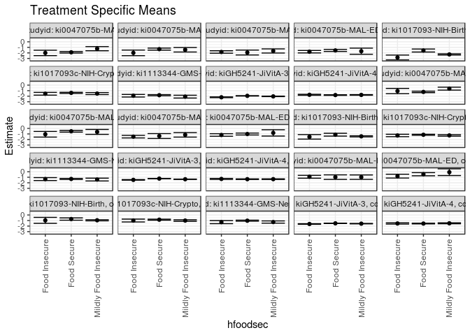

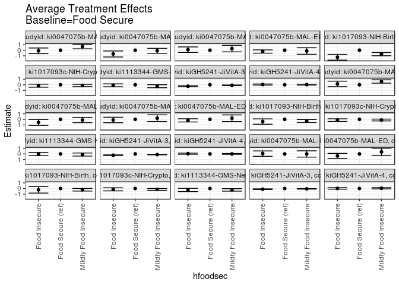

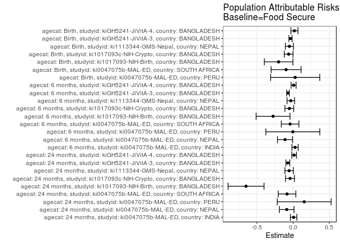

## Results Table

### Parameter: TSM

| agecat | studyid | country | intervention_level | baseline_level | estimate | ci_lower | ci_upper |
| --- | --- | --- | --- | --- | --- | --- | --- |
| Birth | ki0047075b-MAL-ED | PERU | Food Secure | NA | -0.9778095 | -1.3834713 | -0.5721477 |
| Birth | ki0047075b-MAL-ED | PERU | Mildly Food Insecure | NA | -0.9833447 | -1.3809351 | -0.5857544 |
| Birth | ki0047075b-MAL-ED | PERU | Food Insecure | NA | -0.9164168 | -1.1738521 | -0.6589816 |
| Birth | ki0047075b-MAL-ED | SOUTH AFRICA | Food Secure | NA | -0.4535556 | -0.7370575 | -0.1700536 |
| Birth | ki0047075b-MAL-ED | SOUTH AFRICA | Mildly Food Insecure | NA | -0.0888889 | -0.6955550 | 0.5177773 |
| Birth | ki0047075b-MAL-ED | SOUTH AFRICA | Food Insecure | NA | -0.8005882 | -1.1433809 | -0.4577955 |
| Birth | ki1017093-NIH-Birth | BANGLADESH | Food Secure | NA | -0.7312233 | -0.9382606 | -0.5241859 |
| Birth | ki1017093-NIH-Birth | BANGLADESH | Mildly Food Insecure | NA | -0.9536342 | -1.0526788 | -0.8545896 |
| Birth | ki1017093-NIH-Birth | BANGLADESH | Food Insecure | NA | -0.9693631 | -1.5065016 | -0.4322246 |
| Birth | ki1017093c-NIH-Crypto | BANGLADESH | Food Secure | NA | -0.8480327 | -0.9367626 | -0.7593029 |
| Birth | ki1017093c-NIH-Crypto | BANGLADESH | Mildly Food Insecure | NA | -1.0059228 | -1.1450616 | -0.8667839 |
| Birth | ki1017093c-NIH-Crypto | BANGLADESH | Food Insecure | NA | -0.9981410 | -1.2553014 | -0.7409806 |
| Birth | ki1113344-GMS-Nepal | NEPAL | Food Secure | NA | -1.0283021 | -1.1248060 | -0.9317981 |
| Birth | ki1113344-GMS-Nepal | NEPAL | Mildly Food Insecure | NA | -1.2729892 | -1.4738511 | -1.0721272 |
| Birth | ki1113344-GMS-Nepal | NEPAL | Food Insecure | NA | -1.2864455 | -1.5639419 | -1.0089491 |
| Birth | kiGH5241-JiVitA-3 | BANGLADESH | Food Secure | NA | -1.5017620 | -1.5326149 | -1.4709090 |
| Birth | kiGH5241-JiVitA-3 | BANGLADESH | Mildly Food Insecure | NA | -1.5606889 | -1.5997661 | -1.5216118 |
| Birth | kiGH5241-JiVitA-3 | BANGLADESH | Food Insecure | NA | -1.6239414 | -1.6766101 | -1.5712726 |
| Birth | kiGH5241-JiVitA-4 | BANGLADESH | Food Secure | NA | -1.5432898 | -1.6114741 | -1.4751054 |
| Birth | kiGH5241-JiVitA-4 | BANGLADESH | Mildly Food Insecure | NA | -1.4969726 | -1.5829061 | -1.4110390 |
| Birth | kiGH5241-JiVitA-4 | BANGLADESH | Food Insecure | NA | -1.5279081 | -1.6462269 | -1.4095892 |
| 6 months | ki0047075b-MAL-ED | INDIA | Food Secure | NA | -1.2287544 | -1.3589893 | -1.0985195 |
| 6 months | ki0047075b-MAL-ED | INDIA | Mildly Food Insecure | NA | -0.6360000 | -0.9019405 | -0.3700595 |
| 6 months | ki0047075b-MAL-ED | INDIA | Food Insecure | NA | -1.0694118 | -1.5456747 | -0.5931488 |
| 6 months | ki0047075b-MAL-ED | NEPAL | Food Secure | NA | -0.5150621 | -0.6754832 | -0.3546411 |
| 6 months | ki0047075b-MAL-ED | NEPAL | Mildly Food Insecure | NA | -0.6322538 | -1.0758186 | -0.1886890 |
| 6 months | ki0047075b-MAL-ED | NEPAL | Food Insecure | NA | -1.0603097 | -1.5701535 | -0.5504658 |
| 6 months | ki0047075b-MAL-ED | PERU | Food Secure | NA | -1.3749145 | -1.8113590 | -0.9384700 |
| 6 months | ki0047075b-MAL-ED | PERU | Mildly Food Insecure | NA | -1.1601318 | -1.5666492 | -0.7536143 |
| 6 months | ki0047075b-MAL-ED | PERU | Food Insecure | NA | -1.4867290 | -1.7172360 | -1.2562220 |
| 6 months | ki0047075b-MAL-ED | SOUTH AFRICA | Food Secure | NA | -1.0123750 | -1.1877797 | -0.8369704 |
| 6 months | ki0047075b-MAL-ED | SOUTH AFRICA | Mildly Food Insecure | NA | -0.8104353 | -1.3804554 | -0.2404152 |
| 6 months | ki0047075b-MAL-ED | SOUTH AFRICA | Food Insecure | NA | -1.1885425 | -1.4197031 | -0.9573819 |
| 6 months | ki1017093-NIH-Birth | BANGLADESH | Food Secure | NA | -1.1312527 | -1.3869327 | -0.8755726 |
| 6 months | ki1017093-NIH-Birth | BANGLADESH | Mildly Food Insecure | NA | -1.4329668 | -1.5293526 | -1.3365810 |
| 6 months | ki1017093-NIH-Birth | BANGLADESH | Food Insecure | NA | -1.5237410 | -1.9313913 | -1.1160908 |
| 6 months | ki1017093c-NIH-Crypto | BANGLADESH | Food Secure | NA | -1.1466678 | -1.2399386 | -1.0533970 |
| 6 months | ki1017093c-NIH-Crypto | BANGLADESH | Mildly Food Insecure | NA | -1.2609402 | -1.3965565 | -1.1253240 |
| 6 months | ki1017093c-NIH-Crypto | BANGLADESH | Food Insecure | NA | -1.2775224 | -1.4944727 | -1.0605721 |
| 6 months | ki1113344-GMS-Nepal | NEPAL | Food Secure | NA | -1.3110550 | -1.4066715 | -1.2154385 |
| 6 months | ki1113344-GMS-Nepal | NEPAL | Mildly Food Insecure | NA | -1.4193277 | -1.6746110 | -1.1640444 |
| 6 months | ki1113344-GMS-Nepal | NEPAL | Food Insecure | NA | -1.3326051 | -1.5968622 | -1.0683479 |
| 6 months | kiGH5241-JiVitA-3 | BANGLADESH | Food Secure | NA | -1.2424573 | -1.2716418 | -1.2132729 |
| 6 months | kiGH5241-JiVitA-3 | BANGLADESH | Mildly Food Insecure | NA | -1.3607980 | -1.3927501 | -1.3288458 |
| 6 months | kiGH5241-JiVitA-3 | BANGLADESH | Food Insecure | NA | -1.4745207 | -1.5266539 | -1.4223876 |
| 6 months | kiGH5241-JiVitA-4 | BANGLADESH | Food Secure | NA | -1.3518328 | -1.4038126 | -1.2998530 |
| 6 months | kiGH5241-JiVitA-4 | BANGLADESH | Mildly Food Insecure | NA | -1.3467493 | -1.4063927 | -1.2871058 |
| 6 months | kiGH5241-JiVitA-4 | BANGLADESH | Food Insecure | NA | -1.3060229 | -1.3955583 | -1.2164875 |
| 24 months | ki0047075b-MAL-ED | INDIA | Food Secure | NA | -1.8935000 | -2.0301943 | -1.7568057 |
| 24 months | ki0047075b-MAL-ED | INDIA | Mildly Food Insecure | NA | -1.2370000 | -1.6132318 | -0.8607682 |
| 24 months | ki0047075b-MAL-ED | INDIA | Food Insecure | NA | -2.0035294 | -2.4884028 | -1.5186561 |
| 24 months | ki0047075b-MAL-ED | NEPAL | Food Secure | NA | -1.3211336 | -1.5058477 | -1.1364195 |
| 24 months | ki0047075b-MAL-ED | NEPAL | Mildly Food Insecure | NA | -1.4333442 | -1.8360327 | -1.0306557 |
| 24 months | ki0047075b-MAL-ED | NEPAL | Food Insecure | NA | -1.9962907 | -2.4988122 | -1.4937693 |
| 24 months | ki0047075b-MAL-ED | PERU | Food Secure | NA | -1.9312017 | -2.3713182 | -1.4910852 |
| 24 months | ki0047075b-MAL-ED | PERU | Mildly Food Insecure | NA | -1.6452771 | -2.0193654 | -1.2711889 |
| 24 months | ki0047075b-MAL-ED | PERU | Food Insecure | NA | -1.8328063 | -2.0522552 | -1.6133574 |
| 24 months | ki0047075b-MAL-ED | SOUTH AFRICA | Food Secure | NA | -1.5492767 | -1.7328166 | -1.3657367 |
| 24 months | ki0047075b-MAL-ED | SOUTH AFRICA | Mildly Food Insecure | NA | -1.6935349 | -2.2500311 | -1.1370386 |
| 24 months | ki0047075b-MAL-ED | SOUTH AFRICA | Food Insecure | NA | -1.7821367 | -2.0067345 | -1.5575389 |
| 24 months | ki1017093-NIH-Birth | BANGLADESH | Food Secure | NA | -1.5698647 | -1.8417146 | -1.2980149 |
| 24 months | ki1017093-NIH-Birth | BANGLADESH | Mildly Food Insecure | NA | -2.2744975 | -2.3824860 | -2.1665090 |
| 24 months | ki1017093-NIH-Birth | BANGLADESH | Food Insecure | NA | -2.8275161 | -3.2636307 | -2.3914015 |
| 24 months | ki1017093c-NIH-Crypto | BANGLADESH | Food Secure | NA | -1.3992000 | -1.5032603 | -1.2951397 |
| 24 months | ki1017093c-NIH-Crypto | BANGLADESH | Mildly Food Insecure | NA | -1.5245105 | -1.7039856 | -1.3450355 |
| 24 months | ki1017093c-NIH-Crypto | BANGLADESH | Food Insecure | NA | -1.5583072 | -1.8052298 | -1.3113847 |
| 24 months | ki1113344-GMS-Nepal | NEPAL | Food Secure | NA | -1.8212896 | -1.9237521 | -1.7188272 |
| 24 months | ki1113344-GMS-Nepal | NEPAL | Mildly Food Insecure | NA | -2.0786026 | -2.3313250 | -1.8258803 |
| 24 months | ki1113344-GMS-Nepal | NEPAL | Food Insecure | NA | -1.9139758 | -2.1492763 | -1.6786752 |
| 24 months | kiGH5241-JiVitA-3 | BANGLADESH | Food Secure | NA | -1.9375205 | -1.9766966 | -1.8983444 |
| 24 months | kiGH5241-JiVitA-3 | BANGLADESH | Mildly Food Insecure | NA | -2.0318264 | -2.0760200 | -1.9876329 |
| 24 months | kiGH5241-JiVitA-3 | BANGLADESH | Food Insecure | NA | -2.1935906 | -2.2564207 | -2.1307604 |
| 24 months | kiGH5241-JiVitA-4 | BANGLADESH | Food Secure | NA | -1.7943291 | -1.8436181 | -1.7450402 |
| 24 months | kiGH5241-JiVitA-4 | BANGLADESH | Mildly Food Insecure | NA | -1.7694815 | -1.8243816 | -1.7145813 |
| 24 months | kiGH5241-JiVitA-4 | BANGLADESH | Food Insecure | NA | -1.7468532 | -1.8346787 | -1.6590278 |

### Parameter: E(Y)

| agecat | studyid | country | intervention_level | baseline_level | estimate | ci_lower | ci_upper |
| --- | --- | --- | --- | --- | --- | --- | --- |
| Birth | ki0047075b-MAL-ED | PERU | NA | NA | -0.9490110 | -1.1400314 | -0.7579906 |
| Birth | ki0047075b-MAL-ED | SOUTH AFRICA | NA | NA | -0.5503409 | -0.7616444 | -0.3390374 |
| Birth | ki1017093-NIH-Birth | BANGLADESH | NA | NA | -0.9310197 | -1.0197391 | -0.8423003 |
| Birth | ki1017093c-NIH-Crypto | BANGLADESH | NA | NA | -0.9094945 | -0.9809370 | -0.8380521 |
| Birth | ki1113344-GMS-Nepal | NEPAL | NA | NA | -1.0791964 | -1.1604792 | -0.9979137 |
| Birth | kiGH5241-JiVitA-3 | BANGLADESH | NA | NA | -1.5375132 | -1.5596692 | -1.5153573 |
| Birth | kiGH5241-JiVitA-4 | BANGLADESH | NA | NA | -1.5248719 | -1.5743851 | -1.4753587 |
| 6 months | ki0047075b-MAL-ED | INDIA | NA | NA | -1.2019969 | -1.3256948 | -1.0782989 |
| 6 months | ki0047075b-MAL-ED | NEPAL | NA | NA | -0.6262760 | -0.7758267 | -0.4767254 |
| 6 months | ki0047075b-MAL-ED | PERU | NA | NA | -1.3783784 | -1.5611768 | -1.1955799 |
| 6 months | ki0047075b-MAL-ED | SOUTH AFRICA | NA | NA | -1.0539254 | -1.1902766 | -0.9175743 |
| 6 months | ki1017093-NIH-Birth | BANGLADESH | NA | NA | -1.4073821 | -1.4960598 | -1.3187043 |
| 6 months | ki1017093c-NIH-Crypto | BANGLADESH | NA | NA | -1.1986783 | -1.2700937 | -1.1272630 |
| 6 months | ki1113344-GMS-Nepal | NEPAL | NA | NA | -1.3421764 | -1.4201083 | -1.2642445 |
| 6 months | kiGH5241-JiVitA-3 | BANGLADESH | NA | NA | -1.3131326 | -1.3362851 | -1.2899801 |
| 6 months | kiGH5241-JiVitA-4 | BANGLADESH | NA | NA | -1.3446891 | -1.3822219 | -1.3071564 |
| 24 months | ki0047075b-MAL-ED | INDIA | NA | NA | -1.8868396 | -2.0164954 | -1.7571839 |
| 24 months | ki0047075b-MAL-ED | NEPAL | NA | NA | -1.4092187 | -1.5701249 | -1.2483126 |
| 24 months | ki0047075b-MAL-ED | PERU | NA | NA | -1.7783956 | -1.9536701 | -1.6031212 |
| 24 months | ki0047075b-MAL-ED | SOUTH AFRICA | NA | NA | -1.6331323 | -1.7704624 | -1.4958022 |
| 24 months | ki1017093-NIH-Birth | BANGLADESH | NA | NA | -2.2190579 | -2.3217459 | -2.1163699 |
| 24 months | ki1017093c-NIH-Crypto | BANGLADESH | NA | NA | -1.4412646 | -1.5249156 | -1.3576135 |
| 24 months | ki1113344-GMS-Nepal | NEPAL | NA | NA | -1.8758368 | -1.9623349 | -1.7893388 |
| 24 months | kiGH5241-JiVitA-3 | BANGLADESH | NA | NA | -2.0099416 | -2.0377955 | -1.9820876 |
| 24 months | kiGH5241-JiVitA-4 | BANGLADESH | NA | NA | -1.7801485 | -1.8158427 | -1.7444543 |

### Parameter: ATE

| agecat | studyid | country | intervention_level | baseline_level | estimate | ci_lower | ci_upper |
| --- | --- | --- | --- | --- | --- | --- | --- |
| Birth | ki0047075b-MAL-ED | PERU | Food Secure | Food Secure | 0.0000000 | 0.0000000 | 0.0000000 |
| Birth | ki0047075b-MAL-ED | PERU | Mildly Food Insecure | Food Secure | -0.0055352 | -0.5699941 | 0.5589236 |
| Birth | ki0047075b-MAL-ED | PERU | Food Insecure | Food Secure | 0.0613927 | -0.4204336 | 0.5432190 |
| Birth | ki0047075b-MAL-ED | SOUTH AFRICA | Food Secure | Food Secure | 0.0000000 | 0.0000000 | 0.0000000 |
| Birth | ki0047075b-MAL-ED | SOUTH AFRICA | Mildly Food Insecure | Food Secure | 0.3646667 | -0.3049729 | 1.0343063 |
| Birth | ki0047075b-MAL-ED | SOUTH AFRICA | Food Insecure | Food Secure | -0.3470327 | -0.7918699 | 0.0978046 |
| Birth | ki1017093-NIH-Birth | BANGLADESH | Food Secure | Food Secure | 0.0000000 | 0.0000000 | 0.0000000 |
| Birth | ki1017093-NIH-Birth | BANGLADESH | Mildly Food Insecure | Food Secure | -0.2224109 | -0.4519320 | 0.0071101 |
| Birth | ki1017093-NIH-Birth | BANGLADESH | Food Insecure | Food Secure | -0.2381399 | -0.8152685 | 0.3389887 |
| Birth | ki1017093c-NIH-Crypto | BANGLADESH | Food Secure | Food Secure | 0.0000000 | 0.0000000 | 0.0000000 |
| Birth | ki1017093c-NIH-Crypto | BANGLADESH | Mildly Food Insecure | Food Secure | -0.1578900 | -0.3230600 | 0.0072799 |
| Birth | ki1017093c-NIH-Crypto | BANGLADESH | Food Insecure | Food Secure | -0.1501083 | -0.4224213 | 0.1222047 |
| Birth | ki1113344-GMS-Nepal | NEPAL | Food Secure | Food Secure | 0.0000000 | 0.0000000 | 0.0000000 |
| Birth | ki1113344-GMS-Nepal | NEPAL | Mildly Food Insecure | Food Secure | -0.2446871 | -0.4665322 | -0.0228419 |
| Birth | ki1113344-GMS-Nepal | NEPAL | Food Insecure | Food Secure | -0.2581434 | -0.5511203 | 0.0348334 |
| Birth | kiGH5241-JiVitA-3 | BANGLADESH | Food Secure | Food Secure | 0.0000000 | 0.0000000 | 0.0000000 |
| Birth | kiGH5241-JiVitA-3 | BANGLADESH | Mildly Food Insecure | Food Secure | -0.0589269 | -0.1065737 | -0.0112802 |
| Birth | kiGH5241-JiVitA-3 | BANGLADESH | Food Insecure | Food Secure | -0.1221794 | -0.1818486 | -0.0625102 |
| Birth | kiGH5241-JiVitA-4 | BANGLADESH | Food Secure | Food Secure | 0.0000000 | 0.0000000 | 0.0000000 |
| Birth | kiGH5241-JiVitA-4 | BANGLADESH | Mildly Food Insecure | Food Secure | 0.0463172 | -0.0628928 | 0.1555272 |
| Birth | kiGH5241-JiVitA-4 | BANGLADESH | Food Insecure | Food Secure | 0.0153817 | -0.1218226 | 0.1525860 |
| 6 months | ki0047075b-MAL-ED | INDIA | Food Secure | Food Secure | 0.0000000 | 0.0000000 | 0.0000000 |
| 6 months | ki0047075b-MAL-ED | INDIA | Mildly Food Insecure | Food Secure | 0.5927544 | 0.2966371 | 0.8888717 |
| 6 months | ki0047075b-MAL-ED | INDIA | Food Insecure | Food Secure | 0.1593426 | -0.3344058 | 0.6530910 |
| 6 months | ki0047075b-MAL-ED | NEPAL | Food Secure | Food Secure | 0.0000000 | 0.0000000 | 0.0000000 |
| 6 months | ki0047075b-MAL-ED | NEPAL | Mildly Food Insecure | Food Secure | -0.1171917 | -0.5892263 | 0.3548429 |
| 6 months | ki0047075b-MAL-ED | NEPAL | Food Insecure | Food Secure | -0.5452475 | -1.0798709 | -0.0106241 |
| 6 months | ki0047075b-MAL-ED | PERU | Food Secure | Food Secure | 0.0000000 | 0.0000000 | 0.0000000 |
| 6 months | ki0047075b-MAL-ED | PERU | Mildly Food Insecure | Food Secure | 0.2147827 | -0.3839659 | 0.8135313 |
| 6 months | ki0047075b-MAL-ED | PERU | Food Insecure | Food Secure | -0.1118145 | -0.6037541 | 0.3801250 |
| 6 months | ki0047075b-MAL-ED | SOUTH AFRICA | Food Secure | Food Secure | 0.0000000 | 0.0000000 | 0.0000000 |
| 6 months | ki0047075b-MAL-ED | SOUTH AFRICA | Mildly Food Insecure | Food Secure | 0.2019398 | -0.3948934 | 0.7987729 |
| 6 months | ki0047075b-MAL-ED | SOUTH AFRICA | Food Insecure | Food Secure | -0.1761674 | -0.4668051 | 0.1144702 |
| 6 months | ki1017093-NIH-Birth | BANGLADESH | Food Secure | Food Secure | 0.0000000 | 0.0000000 | 0.0000000 |
| 6 months | ki1017093-NIH-Birth | BANGLADESH | Mildly Food Insecure | Food Secure | -0.3017141 | -0.5756681 | -0.0277602 |
| 6 months | ki1017093-NIH-Birth | BANGLADESH | Food Insecure | Food Secure | -0.3924884 | -0.8738339 | 0.0888571 |
| 6 months | ki1017093c-NIH-Crypto | BANGLADESH | Food Secure | Food Secure | 0.0000000 | 0.0000000 | 0.0000000 |
| 6 months | ki1017093c-NIH-Crypto | BANGLADESH | Mildly Food Insecure | Food Secure | -0.1142724 | -0.2788834 | 0.0503386 |
| 6 months | ki1017093c-NIH-Crypto | BANGLADESH | Food Insecure | Food Secure | -0.1308546 | -0.3671999 | 0.1054907 |
| 6 months | ki1113344-GMS-Nepal | NEPAL | Food Secure | Food Secure | 0.0000000 | 0.0000000 | 0.0000000 |
| 6 months | ki1113344-GMS-Nepal | NEPAL | Mildly Food Insecure | Food Secure | -0.1082727 | -0.3810513 | 0.1645059 |
| 6 months | ki1113344-GMS-Nepal | NEPAL | Food Insecure | Food Secure | -0.0215500 | -0.3031233 | 0.2600232 |
| 6 months | kiGH5241-JiVitA-3 | BANGLADESH | Food Secure | Food Secure | 0.0000000 | 0.0000000 | 0.0000000 |
| 6 months | kiGH5241-JiVitA-3 | BANGLADESH | Mildly Food Insecure | Food Secure | -0.1183406 | -0.1558398 | -0.0808415 |
| 6 months | kiGH5241-JiVitA-3 | BANGLADESH | Food Insecure | Food Secure | -0.2320634 | -0.2887554 | -0.1753714 |
| 6 months | kiGH5241-JiVitA-4 | BANGLADESH | Food Secure | Food Secure | 0.0000000 | 0.0000000 | 0.0000000 |
| 6 months | kiGH5241-JiVitA-4 | BANGLADESH | Mildly Food Insecure | Food Secure | 0.0050835 | -0.0711307 | 0.0812976 |
| 6 months | kiGH5241-JiVitA-4 | BANGLADESH | Food Insecure | Food Secure | 0.0458098 | -0.0571762 | 0.1487958 |
| 24 months | ki0047075b-MAL-ED | INDIA | Food Secure | Food Secure | 0.0000000 | 0.0000000 | 0.0000000 |
| 24 months | ki0047075b-MAL-ED | INDIA | Mildly Food Insecure | Food Secure | 0.6565000 | 0.2562055 | 1.0567945 |
| 24 months | ki0047075b-MAL-ED | INDIA | Food Insecure | Food Secure | -0.1100294 | -0.6138027 | 0.3937438 |
| 24 months | ki0047075b-MAL-ED | NEPAL | Food Secure | Food Secure | 0.0000000 | 0.0000000 | 0.0000000 |
| 24 months | ki0047075b-MAL-ED | NEPAL | Mildly Food Insecure | Food Secure | -0.1122106 | -0.5542273 | 0.3298060 |
| 24 months | ki0047075b-MAL-ED | NEPAL | Food Insecure | Food Secure | -0.6751572 | -1.2104263 | -0.1398880 |
| 24 months | ki0047075b-MAL-ED | PERU | Food Secure | Food Secure | 0.0000000 | 0.0000000 | 0.0000000 |
| 24 months | ki0047075b-MAL-ED | PERU | Mildly Food Insecure | Food Secure | 0.2859246 | -0.2989130 | 0.8707622 |
| 24 months | ki0047075b-MAL-ED | PERU | Food Insecure | Food Secure | 0.0983954 | -0.3950906 | 0.5918815 |
| 24 months | ki0047075b-MAL-ED | SOUTH AFRICA | Food Secure | Food Secure | 0.0000000 | 0.0000000 | 0.0000000 |
| 24 months | ki0047075b-MAL-ED | SOUTH AFRICA | Mildly Food Insecure | Food Secure | -0.1442582 | -0.7302109 | 0.4416945 |
| 24 months | ki0047075b-MAL-ED | SOUTH AFRICA | Food Insecure | Food Secure | -0.2328600 | -0.5231506 | 0.0574305 |
| 24 months | ki1017093-NIH-Birth | BANGLADESH | Food Secure | Food Secure | 0.0000000 | 0.0000000 | 0.0000000 |
| 24 months | ki1017093-NIH-Birth | BANGLADESH | Mildly Food Insecure | Food Secure | -0.7046328 | -0.9969205 | -0.4123451 |
| 24 months | ki1017093-NIH-Birth | BANGLADESH | Food Insecure | Food Secure | -1.2576513 | -1.7711538 | -0.7441489 |
| 24 months | ki1017093c-NIH-Crypto | BANGLADESH | Food Secure | Food Secure | 0.0000000 | 0.0000000 | 0.0000000 |
| 24 months | ki1017093c-NIH-Crypto | BANGLADESH | Mildly Food Insecure | Food Secure | -0.1253106 | -0.3318788 | 0.0812577 |
| 24 months | ki1017093c-NIH-Crypto | BANGLADESH | Food Insecure | Food Secure | -0.1591073 | -0.4260925 | 0.1078780 |
| 24 months | ki1113344-GMS-Nepal | NEPAL | Food Secure | Food Secure | 0.0000000 | 0.0000000 | 0.0000000 |
| 24 months | ki1113344-GMS-Nepal | NEPAL | Mildly Food Insecure | Food Secure | -0.2573130 | -0.5298865 | 0.0152605 |
| 24 months | ki1113344-GMS-Nepal | NEPAL | Food Insecure | Food Secure | -0.0926861 | -0.3491427 | 0.1637704 |
| 24 months | kiGH5241-JiVitA-3 | BANGLADESH | Food Secure | Food Secure | 0.0000000 | 0.0000000 | 0.0000000 |
| 24 months | kiGH5241-JiVitA-3 | BANGLADESH | Mildly Food Insecure | Food Secure | -0.0943059 | -0.1503996 | -0.0382123 |
| 24 months | kiGH5241-JiVitA-3 | BANGLADESH | Food Insecure | Food Secure | -0.2560701 | -0.3249750 | -0.1871651 |
| 24 months | kiGH5241-JiVitA-4 | BANGLADESH | Food Secure | Food Secure | 0.0000000 | 0.0000000 | 0.0000000 |
| 24 months | kiGH5241-JiVitA-4 | BANGLADESH | Mildly Food Insecure | Food Secure | 0.0248477 | -0.0457172 | 0.0954126 |
| 24 months | kiGH5241-JiVitA-4 | BANGLADESH | Food Insecure | Food Secure | 0.0474759 | -0.0510943 | 0.1460462 |

### Parameter: PAR

| agecat | studyid | country | intervention_level | baseline_level | estimate | ci_lower | ci_upper |
| --- | --- | --- | --- | --- | --- | --- | --- |
| Birth | ki0047075b-MAL-ED | PERU | Food Secure | NA | 0.0287985 | -0.3103644 | 0.3679615 |
| Birth | ki0047075b-MAL-ED | SOUTH AFRICA | Food Secure | NA | -0.0967854 | -0.3037214 | 0.1101506 |
| Birth | ki1017093-NIH-Birth | BANGLADESH | Food Secure | NA | -0.1997965 | -0.3966569 | -0.0029361 |
| Birth | ki1017093c-NIH-Crypto | BANGLADESH | Food Secure | NA | -0.0614618 | -0.1223421 | -0.0005816 |
| Birth | ki1113344-GMS-Nepal | NEPAL | Food Secure | NA | -0.0508944 | -0.1066348 | 0.0048461 |
| Birth | kiGH5241-JiVitA-3 | BANGLADESH | Food Secure | NA | -0.0357512 | -0.0581171 | -0.0133854 |
| Birth | kiGH5241-JiVitA-4 | BANGLADESH | Food Secure | NA | 0.0184179 | -0.0300420 | 0.0668778 |
| 6 months | ki0047075b-MAL-ED | INDIA | Food Secure | NA | 0.0267575 | -0.0163737 | 0.0698887 |
| 6 months | ki0047075b-MAL-ED | NEPAL | Food Secure | NA | -0.1112139 | -0.2152327 | -0.0071952 |
| 6 months | ki0047075b-MAL-ED | PERU | Food Secure | NA | -0.0034639 | -0.3756217 | 0.3686938 |
| 6 months | ki0047075b-MAL-ED | SOUTH AFRICA | Food Secure | NA | -0.0415504 | -0.1629108 | 0.0798100 |
| 6 months | ki1017093-NIH-Birth | BANGLADESH | Food Secure | NA | -0.2761294 | -0.5099712 | -0.0422875 |
| 6 months | ki1017093c-NIH-Crypto | BANGLADESH | Food Secure | NA | -0.0520105 | -0.1122257 | 0.0082047 |
| 6 months | ki1113344-GMS-Nepal | NEPAL | Food Secure | NA | -0.0311214 | -0.0835138 | 0.0212710 |
| 6 months | kiGH5241-JiVitA-3 | BANGLADESH | Food Secure | NA | -0.0706753 | -0.0889435 | -0.0524071 |
| 6 months | kiGH5241-JiVitA-4 | BANGLADESH | Food Secure | NA | 0.0071436 | -0.0273567 | 0.0416440 |
| 24 months | ki0047075b-MAL-ED | INDIA | Food Secure | NA | 0.0066604 | -0.0380987 | 0.0514195 |
| 24 months | ki0047075b-MAL-ED | NEPAL | Food Secure | NA | -0.0880852 | -0.1889413 | 0.0127710 |
| 24 months | ki0047075b-MAL-ED | PERU | Food Secure | NA | 0.1528061 | -0.2192440 | 0.5248562 |
| 24 months | ki0047075b-MAL-ED | SOUTH AFRICA | Food Secure | NA | -0.0838556 | -0.2052596 | 0.0375483 |
| 24 months | ki1017093-NIH-Birth | BANGLADESH | Food Secure | NA | -0.6491931 | -0.8973304 | -0.4010559 |
| 24 months | ki1017093c-NIH-Crypto | BANGLADESH | Food Secure | NA | -0.0420646 | -0.1038514 | 0.0197222 |
| 24 months | ki1113344-GMS-Nepal | NEPAL | Food Secure | NA | -0.0545472 | -0.1123797 | 0.0032854 |
| 24 months | kiGH5241-JiVitA-3 | BANGLADESH | Food Secure | NA | -0.0724211 | -0.0992577 | -0.0455844 |
| 24 months | kiGH5241-JiVitA-4 | BANGLADESH | Food Secure | NA | 0.0141806 | -0.0176905 | 0.0460518 |